# Project Python Foundations: FoodHub Data Analysis

### Context

The number of restaurants in New York is increasing day by day. Lots of students and busy professionals rely on those restaurants due to their hectic lifestyles. Online food delivery service is a great option for them. It provides them with good food from their favorite restaurants. A food aggregator company FoodHub offers access to multiple restaurants through a single smartphone app.

The app allows the restaurants to receive a direct online order from a customer. The app assigns a delivery person from the company to pick up the order after it is confirmed by the restaurant. The delivery person then uses the map to reach the restaurant and waits for the food package. Once the food package is handed over to the delivery person, he/she confirms the pick-up in the app and travels to the customer's location to deliver the food. The delivery person confirms the drop-off in the app after delivering the food package to the customer. The customer can rate the order in the app. The food aggregator earns money by collecting a fixed margin of the delivery order from the restaurants.

### Objective

The food aggregator company has stored the data of the different orders made by the registered customers in their online portal. They want to analyze the data to get a fair idea about the demand of different restaurants which will help them in enhancing their customer experience. Suppose you are hired as a Data Scientist in this company and the Data Science team has shared some of the key questions that need to be answered. Perform the data analysis to find answers to these questions that will help the company to improve the business.

### Data Description

The data contains the different data related to a food order. The detailed data dictionary is given below.

### Data Dictionary

- order_id: Unique ID of the order
- customer_id: ID of the customer who ordered the food
- restaurant_name: Name of the restaurant
- cuisine_type: Cuisine ordered by the customer
- cost_of_the_order: Cost of the order
- day_of_the_week: Indicates whether the order is placed on a weekday or weekend (The weekday is from Monday to Friday and the weekend is Saturday and Sunday)
- rating: Rating given by the customer out of 5
- food_preparation_time: Time (in minutes) taken by the restaurant to prepare the food. This is calculated by taking the difference between the timestamps of the restaurant's order confirmation and the delivery person's pick-up confirmation.
- delivery_time: Time (in minutes) taken by the delivery person to deliver the food package. This is calculated by taking the difference between the timestamps of the delivery person's pick-up confirmation and drop-off information

### Let us start by importing the required libraries

```python
# Installing the libraries with the specified version.
#!pip install numpy==1.25.2 pandas==1.5.3 matplotlib==3.7.1 seaborn==0.13.1 -q --user

# change to support python 3.12.12 version
#!pip install -U pip setuptools wheel
!pip install numpy>=1.26 pandas>=2.2 matplotlib>=3.9 seaborn>=0.13 -q --user
```

**Note**:

- After running the above cell, kindly restart the runtime (for Google Colab) or notebook kernel (for Jupyter Notebook), and run all cells sequentially from the next cell.
- On executing the above line of code, you might see a warning regarding package dependencies. This error message can be ignored as the above code ensures that all necessary libraries and their dependencies are maintained to successfully execute the code in **this notebook**.

```python
# import libraries for data manipulation
import numpy as np
import pandas as pd

# import libraries for data visualization
import matplotlib.pyplot as plt
import seaborn as sns
```

### Understanding the structure of the data

```python
# uncomment and run the below code snippets if the dataset is present in the Google Drive
# from google.colab import drive
# drive.mount('/content/drive')
```

```python
# Write your code here to read the data
reviews = pd.read_csv("foodhub_order.csv")
```

```python
# creating a copy of the data
data = reviews.copy()
```

```python
# Write your code here to view the first 5 rows
data.head(5)
```

|  | order_id | customer_id | restaurant_name | cuisine_type | cost_of_the_order | day_of_the_week | rating | food_preparation_time | delivery_time |
| --- | --- | --- | --- | --- | --- | --- | --- | --- | --- |
| 0 | 1477147 | 337525 | Hangawi | Korean | 30.75 | Weekend | Not given | 25 | 20 |
| 1 | 1477685 | 358141 | Blue Ribbon Sushi Izakaya | Japanese | 12.08 | Weekend | Not given | 25 | 23 |
| 2 | 1477070 | 66393 | Cafe Habana | Mexican | 12.23 | Weekday | 5 | 23 | 28 |
| 3 | 1477334 | 106968 | Blue Ribbon Fried Chicken | American | 29.20 | Weekend | 3 | 25 | 15 |
| 4 | 1478249 | 76942 | Dirty Bird to Go | American | 11.59 | Weekday | 4 | 25 | 24 |

### **Question 1:** How many rows and columns are present in the data? [0.5 mark]

```python
# Write your code here
# shape of data
data.shape
```

```
(1898, 9)
```

#### Observations:

# row= 1898

# column= 9

### **Question 2:** What are the datatypes of the different columns in the dataset? (The info() function can be used) [0.5 mark]

```python
# Write your code here
# Display basic information about the dataset
print("Dataset Info:")
data.info()

# datatypes only
print("\nColumn Data Types:")
print(data.dtypes)
```

```
Dataset Info:
<class 'pandas.core.frame.DataFrame'>
RangeIndex: 1898 entries, 0 to 1897
Data columns (total 9 columns):
 #   Column                 Non-Null Count  Dtype
---  ------                 --------------  -----
 0   order_id               1898 non-null   int64
 1   customer_id            1898 non-null   int64
 2   restaurant_name        1898 non-null   object
 3   cuisine_type           1898 non-null   object
 4   cost_of_the_order      1898 non-null   float64
 5   day_of_the_week        1898 non-null   object
 6   rating                 1898 non-null   object
 7   food_preparation_time  1898 non-null   int64
 8   delivery_time          1898 non-null   int64
dtypes: float64(1), int64(4), object(4)
memory usage: 133.6+ KB

Column Data Types:
order_id                   int64
customer_id                int64
restaurant_name           object
cuisine_type              object
cost_of_the_order        float64
day_of_the_week           object
rating                    object
food_preparation_time      int64
delivery_time              int64
dtype: object
```

#### Observations:

Column Data Types: order_id int64 customer_id int64 restaurant_name object cuisine_type object cost_of_the_order float64 day_of_the_week object rating object food_preparation_time int64 delivery_time int64 dtype: object

### **Question 3:** Are there any missing values in the data? If yes, treat them using an appropriate method. [1 mark]

```python
# Write your code here
data.isnull().sum()
```

|  | 0 |
| --- | --- |
| order_id | 0 |
| customer_id | 0 |
| restaurant_name | 0 |
| cuisine_type | 0 |
| cost_of_the_order | 0 |
| day_of_the_week | 0 |
| rating | 0 |
| food_preparation_time | 0 |
| delivery_time | 0 |

**dtype:** int64

#### Observations:

There is no missing values in data

### **Question 4:** Check the statistical summary of the data. What is the minimum, average, and maximum time it takes for food to be prepared once an order is placed? [2 marks]

```python
# Write your code here
min_time = data['food_preparation_time'].min()
avg_time = data['food_preparation_time'].mean()
max_time = data['food_preparation_time'].max()

print(f"Minimum preparation time: {min_time} minutes")
print(f"Average preparation time: {avg_time:.2f} minutes")
print(f"Maximum preparation time: {max_time} minutes")
```

```
Minimum preparation time: 20 minutes
Average preparation time: 27.37 minutes
Maximum preparation time: 35 minutes
```

#### Observations:

Minimum preparation time: 20 minutes Average preparation time: 27.37 minutes Maximum preparation time: 35 minutes

### **Question 5:** How many orders are not rated? [1 mark]

```python
# Write the code here
# Count of missing (NaN) ratings
missing_ratings = data['rating'].isna().sum()

# Also count blank or empty string ratings (if any)
blank_ratings = (data['rating'].astype(str).str.strip() == '').sum()

# Total not-rated orders
total_not_rated = missing_ratings + blank_ratings

print(f"Number of orders not rated: {total_not_rated}")
```

[output not shown]

### Exploratory Data Analysis (EDA)

### **Question 6:** Explore all the variables and provide observations on their distributions. (Generally, histograms, boxplots, countplots, etc. are used for univariate exploration.) [9 marks]

```python
# Write the code here
import pandas as pd
import matplotlib.pyplot as plt
import seaborn as sns

# Ensure plots look good
plt.style.use("seaborn-v0_8")
sns.set_palette("coolwarm")

# Load and copy dataset
reviews = pd.read_csv("foodhub_order.csv")
data = reviews.copy()
```

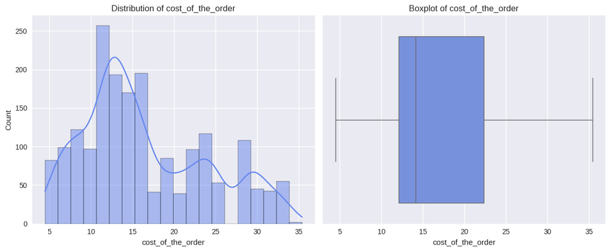

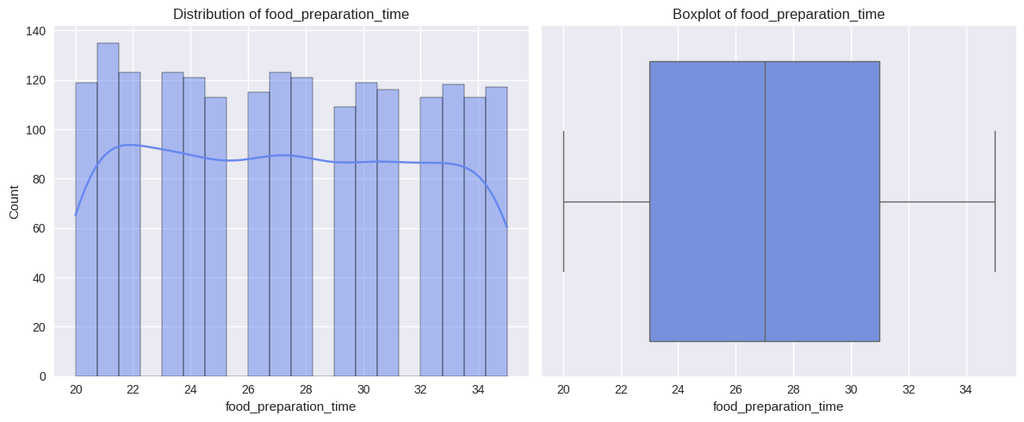

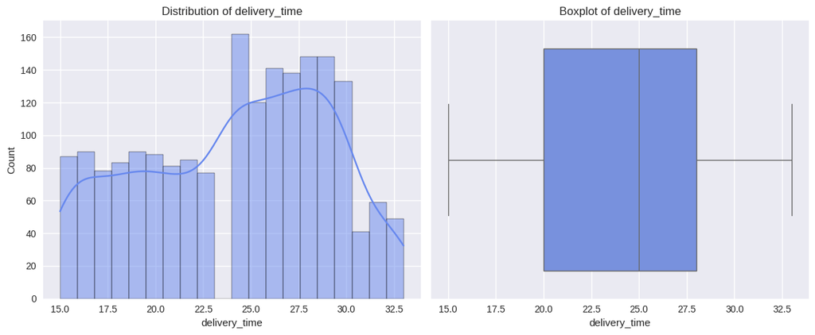

```python
# Numerical columns (from your list):
# cost_of_the_order
# food_preparation_time
# delivery_time

num_cols = ['cost_of_the_order', 'food_preparation_time', 'delivery_time']

for col in num_cols:
    plt.figure(figsize=(12, 5))

    # Histogram
    plt.subplot(1, 2, 1)
    sns.histplot(data[col], kde=True, bins=20)
    plt.title(f"Distribution of {col}")

    # Boxplot
    plt.subplot(1, 2, 2)
    sns.boxplot(x=data[col])
    plt.title(f"Boxplot of {col}")

    plt.tight_layout()
    plt.show()
```

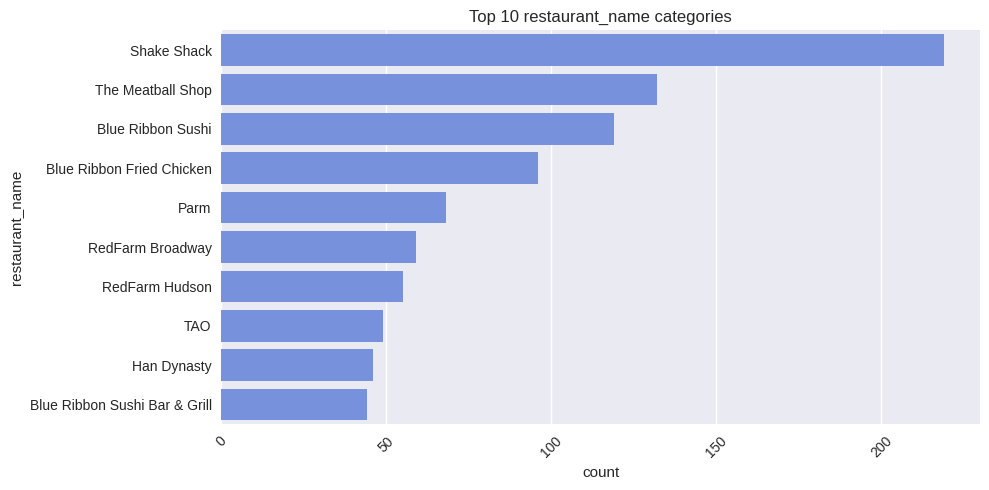

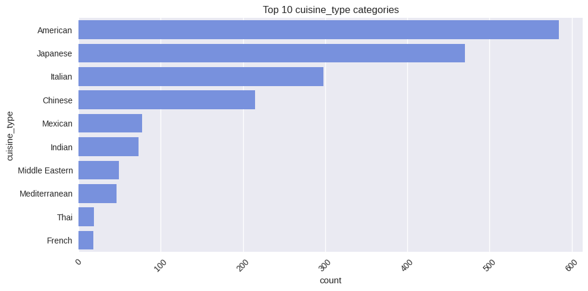

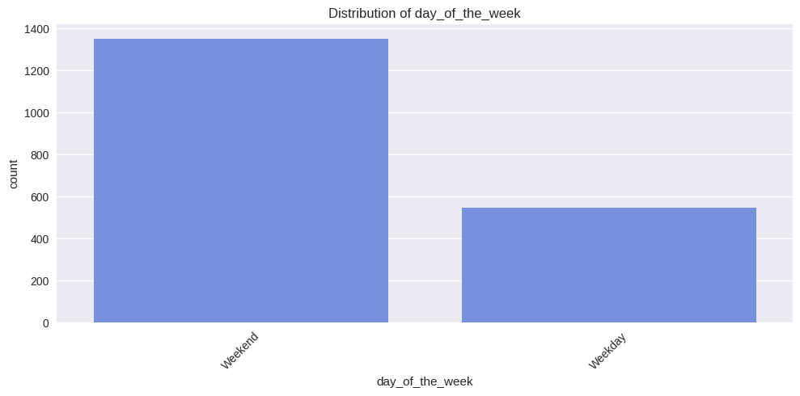

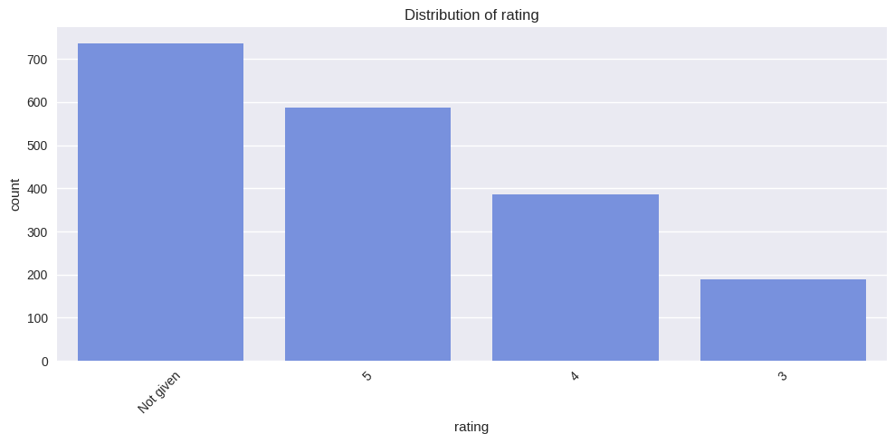

```python
#Categorical Variables — Countplots
# Categorical columns:
# restaurant_name
# cuisine_type
# day_of_the_week
# rating

# top 10 resturant
cat_cols = ['restaurant_name', 'cuisine_type', 'day_of_the_week', 'rating']

for col in cat_cols:
    plt.figure(figsize=(10, 5))
    if col in ['restaurant_name', 'cuisine_type']:
        top_values = data[col].value_counts().head(10).index
        sns.countplot(y=data[col], order=top_values)
        plt.title(f"Top 10 {col} categories")
    else:
        sns.countplot(x=data[col], order=data[col].value_counts().index)
        plt.title(f"Distribution of {col}")

    plt.xticks(rotation=45)
    plt.tight_layout()
    plt.show()
```

### **Question 7**: Which are the top 5 restaurants in terms of the number of orders received? [1 mark]

```python
# Write the code here
# Top 5 restaurants by number of orders
top_5_restaurants = data['restaurant_name'].value_counts().head(5)

print("Top 5 Restaurants by Number of Orders:")
print(top_5_restaurants)
```

```
Top 5 Restaurants by Number of Orders:
restaurant_name
Shake Shack                  219
The Meatball Shop            132
Blue Ribbon Sushi            119
Blue Ribbon Fried Chicken     96
Parm                          68
Name: count, dtype: int64
```

#### Observations:

Top 5 Restaurants by Number of Orders: restaurant_name Shake Shack 219 The Meatball Shop 132 Blue Ribbon Sushi 119 Blue Ribbon Fried Chicken 96 Parm 68

### **Question 8**: Which is the most popular cuisine on weekends? [1 mark]

```python
# Filter for weekend orders
weekend_orders = data[data['day_of_the_week'] == 'Weekend']

# Find the most popular cuisine
popular_cuisine_weekends = weekend_orders['cuisine_type'].value_counts().idxmax()

print(f"The most popular cuisine on weekends is: {popular_cuisine_weekends}")
```

```
The most popular cuisine on weekends is: American
```

#### Observations:

The most popular cuisine on weekends is: American

### **Question 9**: What percentage of the orders cost more than 20 dollars? [2 marks]

```python
# Write the code here
# Total number of orders
total_orders = len(data)

# Orders where cost is greater than $20
orders_above_20 = data[data['cost_of_the_order'] > 20].shape[0]

# Percentage calculation
percentage_above_20 = (orders_above_20 / total_orders) * 100

print(f"Percentage of orders costing more than $20: {percentage_above_20:.2f}%")
```

```
Percentage of orders costing more than $20: 29.24%
```

#### Observations:

Percentage of orders costing more than $20: 29.24%

### **Question 10**: What is the mean order delivery time? [1 mark]

```python
# Write the code here
mean_delivery_time = data['delivery_time'].mean()
print(f"Mean order delivery time: {mean_delivery_time:.2f} minutes")
```

```
Mean order delivery time: 24.16 minutes
```

#### Observations:

Mean order delivery time: 24.16 minutes

### **Question 11:** The company has decided to give 20% discount vouchers to the top 3 most frequent customers. Find the IDs of these customers and the number of orders they placed. [1 mark]

```python
# Write the code here
# Find top 3 customers by number of orders
top_customers = data['customer_id'].value_counts().head(3)

print("Top 3 most frequent customers and their order counts:")
print(top_customers)
```

```
Top 3 most frequent customers and their order counts:
customer_id
52832    13
47440    10
83287     9
Name: count, dtype: int64
```

#### Observations:

Top 3 most frequent customers and their order counts: customer_id 52832 13 47440 10 83287 9

### **Question 12**: Perform a multivariate analysis to explore relationships between the important variables in the dataset. (It is a good idea to explore relations between numerical variables as well as relations between numerical and categorical variables) [10 marks]

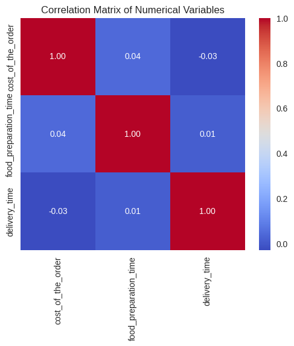

```python
# Write the code here
import seaborn as sns
import matplotlib.pyplot as plt

num_cols = ['cost_of_the_order', 'food_preparation_time', 'delivery_time']

# Correlation matrix
corr = data[num_cols].corr()

plt.figure(figsize=(6,5))
sns.heatmap(corr, annot=True, cmap='coolwarm', fmt=".2f")
plt.title("Correlation Matrix of Numerical Variables")
plt.show()
```

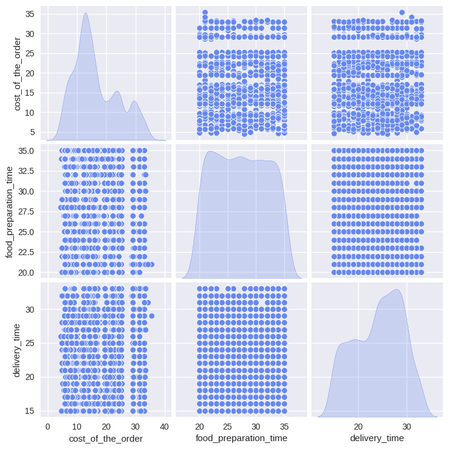

```python
sns.pairplot(data[num_cols], kind='scatter', diag_kind='kde')
plt.show()
```

### **Question 13:** The company wants to provide a promotional offer in the advertisement of the restaurants. The condition to get the offer is that the restaurants must have a rating count of more than 50 and the average rating should be greater than 4. Find the restaurants fulfilling the criteria to get the promotional offer. [3 marks]

```python
# Write the code here
# Convert rating to numeric (coerce errors to NaN)
data['rating'] = pd.to_numeric(data['rating'], errors='coerce')

# Group by restaurant and calculate count and mean of ratings
restaurant_ratings = data.groupby('restaurant_name')['rating'].agg(['count', 'mean']).reset_index()

# Filter restaurants meeting the criteria
promotional_restaurants = restaurant_ratings[
    (restaurant_ratings['count'] > 50) & (restaurant_ratings['mean'] > 4)
]

print("Restaurants eligible for promotional offer:")
print(promotional_restaurants)
```

```
Restaurants eligible for promotional offer:
               restaurant_name  count      mean
20   Blue Ribbon Fried Chicken     64  4.328125
21           Blue Ribbon Sushi     73  4.219178
136                Shake Shack    133  4.278195
153          The Meatball Shop     84  4.511905
```

#### Observations:

Restaurants eligible for promotional offer: restaurant_name count mean 20 Blue Ribbon Fried Chicken 64 4.328125 21 Blue Ribbon Sushi 73 4.219178 136 Shake Shack 133 4.278195 153 The Meatball Shop 84 4.511905

### **Question 14:** The company charges the restaurant 25% on the orders having cost greater than 20 dollars and 15% on the orders having cost greater than 5 dollars. Find the net revenue generated by the company across all orders. [3 marks]

```python
# Initialize revenue column as float
data['company_revenue'] = 0.0

# Apply 25% for orders > $20
data.loc[data['cost_of_the_order'] > 20, 'company_revenue'] = 0.25 * data['cost_of_the_order']

# Apply 15% for orders > $5 and ≤ $20
mask = (data['cost_of_the_order'] > 5) & (data['cost_of_the_order'] <= 20)
data.loc[mask, 'company_revenue'] = 0.15 * data['cost_of_the_order']

# Net revenue
net_revenue = data['company_revenue'].sum()
print(f"Net revenue generated by the company: ${net_revenue:.2f}")
```

```
Net revenue generated by the company: $6166.30
```

#### Observations:

Net revenue generated by the company: $6166.30

### **Question 15:** The company wants to analyze the total time required to deliver the food. What percentage of orders take more than 60 minutes to get delivered from the time the order is placed? (The food has to be prepared and then delivered.) [2 marks]

```python
# Write the code here
# Calculate total time for each order
data['total_time'] = data['food_preparation_time'] + data['delivery_time']

# Total number of orders
total_orders = len(data)

# Orders taking more than 60 minutes
orders_over_60 = (data['total_time'] > 60).sum()

# Percentage
percentage_over_60 = (orders_over_60 / total_orders) * 100

print(f"Percentage of orders taking more than 60 minutes: {percentage_over_60:.2f}%")
```

```
Percentage of orders taking more than 60 minutes: 10.54%
```

#### Observations:

Percentage of orders taking more than 60 minutes: 10.54%

### **Question 16:** The company wants to analyze the delivery time of the orders on weekdays and weekends. How does the mean delivery time vary during weekdays and weekends? [2 marks]

```python
# Write the code here

# Ensure day_of_the_week is clean
data['day_of_the_week'] = data['day_of_the_week'].str.strip().str.title()

# Calculate mean delivery time by day type
mean_delivery_by_day = data.groupby('day_of_the_week')['delivery_time'].mean()

print("Mean delivery time by day type:")
print(mean_delivery_by_day)
```

```
Mean delivery time by day type:
day_of_the_week
Weekday    28.340037
Weekend    22.470022
Name: delivery_time, dtype: float64
```

#### Observations:

day_of_the_week Weekday 28.340037 Weekend 22.470022

### Conclusion and Recommendations

### **Question 17:** What are your conclusions from the analysis? What recommendations would you like to share to help improve the business? (You can use cuisine type and feedback ratings to drive your business recommendations.) [6 marks]

### Conclusions:

- Focusing on high-value customers, high-rated restaurants, popular cuisines, and operational efficiency will help improve revenue, customer satisfaction, and overall business performance.

### Recommendations:

Following are the recommendations

### Promotions and Discounts

- Target top 3 frequent customers with personalized discounts to encourage repeat orders.
- Promote high-rated restaurants (>50 ratings and avg rating >4) in advertisements to attract new customers.

### Revenue Optimization

- Encourage higher-value orders (> $20) through bundle offers or special deals since they generate more revenue for the platform.
- Analyze low-cost orders (≤ $5) to determine if offering promotions can increase their frequency and profitability.

### Customer Engagement and Loyalty

- Implement loyalty programs based on order frequency and ratings to retain high-value customers.
- Gather additional feedback from low-rated orders to identify pain points and improve service quality.

### Visualization and Reporting

- Use dashboards to track order trends, revenue, and delivery efficiency by cuisine, restaurant, and day type.
- Continuously monitor key KPIs like mean delivery time, top restaurants, and customer ratings to guide decision-making.